# Houses Prices Prediction

- **Name**: Oded Nir
- **ID**: 205985948
- [**My Kaggle Profile Page Direct Link**](https://www.kaggle.com/odednir)

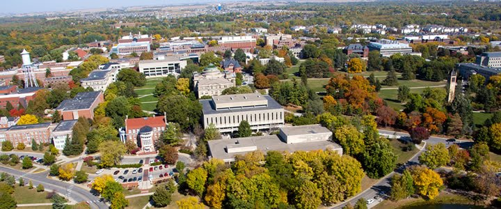

## Features description:

- SalePrice - the property's sale price in dollars. This is the target variable that you're trying to predict.
- MSSubClass: The building class
- MSZoning: The general zoning classification
- LotFrontage: Linear feet of street connected to property
- LotArea: Lot size in square feet
- Street: Type of road access
- Alley: Type of alley access
- LotShape: General shape of property
- LandContour: Flatness of the property
- Utilities: Type of utilities available
- LotConfig: Lot configuration
- LandSlope: Slope of property
- Neighborhood: Physical locations within Ames city limits
- Condition1: Proximity to main road or railroad
- Condition2: Proximity to main road or railroad (if a second is present)
- BldgType: Type of dwelling
- HouseStyle: Style of dwelling
- OverallQual: Overall material and finish quality
- OverallCond: Overall condition rating
- YearBuilt: Original construction date
- YearRemodAdd: Remodel date
- RoofStyle: Type of roof
- RoofMatl: Roof material
- Exterior1st: Exterior covering on house
- Exterior2nd: Exterior covering on house (if more than one material)
- MasVnrType: Masonry veneer type
- MasVnrArea: Masonry veneer area in square feet
- ExterQual: Exterior material quality
- ExterCond: Present condition of the material on the exterior
- Foundation: Type of foundation
- BsmtQual: Height of the basement
- BsmtCond: General condition of the basement
- BsmtExposure: Walkout or garden level basement walls
- BsmtFinType1: Quality of basement finished area
- BsmtFinSF1: Type 1 finished square feet
- BsmtFinType2: Quality of second finished area (if present)
- BsmtFinSF2: Type 2 finished square feet
- BsmtUnfSF: Unfinished square feet of basement area
- TotalBsmtSF: Total square feet of basement area
- Heating: Type of heating
- HeatingQC: Heating quality and condition
- CentralAir: Central air conditioning
- Electrical: Electrical system
- 1stFlrSF: First Floor square feet
- 2ndFlrSF: Second floor square feet
- LowQualFinSF: Low quality finished square feet (all floors)
- GrLivArea: Above grade (ground) living area square feet
- BsmtFullBath: Basement full bathrooms
- BsmtHalfBath: Basement half bathrooms
- FullBath: Full bathrooms above grade
- HalfBath: Half baths above grade
- Bedroom: Number of bedrooms above basement level
- Kitchen: Number of kitchens
- KitchenQual: Kitchen quality
- TotRmsAbvGrd: Total rooms above grade (does not include bathrooms)
- Functional: Home functionality rating
- Fireplaces: Number of fireplaces
- FireplaceQu: Fireplace quality
- GarageType: Garage location
- GarageYrBlt: Year garage was built
- GarageFinish: Interior finish of the garage
- GarageCars: Size of garage in car capacity
- GarageArea: Size of garage in square feet
- GarageQual: Garage quality
- GarageCond: Garage condition
- PavedDrive: Paved driveway
- WoodDeckSF: Wood deck area in square feet
- OpenPorchSF: Open porch area in square feet
- EnclosedPorch: Enclosed porch area in square feet
- 3SsnPorch: Three season porch area in square feet
- ScreenPorch: Screen porch area in square feet
- PoolArea: Pool area in square feet
- PoolQC: Pool quality
- Fence: Fence quality
- MiscFeature: Miscellaneous feature not covered in other categories
- MiscVal: $Value of miscellaneous feature
- MoSold: Month Sold
- YrSold: Year Sold
- SaleType: Type of sale
- SaleCondition: Condition of sale

## Loading Data Description

```python
description = open('/kaggle/input/house-prices-advanced-regression-techniques/data_description.txt')
print(description.read())
```

```
MSSubClass: Identifies the type of dwelling involved in the sale.

        20	1-STORY 1946 & NEWER ALL STYLES
        30	1-STORY 1945 & OLDER
        40	1-STORY W/FINISHED ATTIC ALL AGES
        45	1-1/2 STORY - UNFINISHED ALL AGES
        50	1-1/2 STORY FINISHED ALL AGES
        60	2-STORY 1946 & NEWER
        70	2-STORY 1945 & OLDER
        75	2-1/2 STORY ALL AGES
        80	SPLIT OR MULTI-LEVEL
        85	SPLIT FOYER
        90	DUPLEX - ALL STYLES AND AGES
       120	1-STORY PUD (Planned Unit Development) - 1946 & NEWER
       150	1-1/2 STORY PUD - ALL AGES
       160	2-STORY PUD - 1946 & NEWER
       180	PUD - MULTILEVEL - INCL SPLIT LEV/FOYER
       190	2 FAMILY CONVERSION - ALL STYLES AND AGES

MSZoning: Identifies the general zoning classification of the sale.

       A	Agriculture
       C	Commercial
       FV	Floating Village Residential
       I	Industrial
       RH	Residential High Density
       RL	Residential Low Density
       RP	Residential Low Density Park
       RM	Residential Medium Density

LotFrontage: Linear feet of street connected to property

LotArea: Lot size in square feet

Street: Type of road access to property

       Grvl	Gravel
       Pave	Paved

Alley: Type of alley access to property
```

[output cut: 468 more lines]

```
       COD	Court Officer Deed/Estate
       Con	Contract 15% Down payment regular terms
       ConLw	Contract Low Down payment and low interest
       ConLI	Contract Low Interest
       ConLD	Contract Low Down
       Oth	Other

SaleCondition: Condition of sale

       Normal	Normal Sale
       Abnorml	Abnormal Sale -  trade, foreclosure, short sale
       AdjLand	Adjoining Land Purchase
       Alloca	Allocation - two linked properties with separate deeds, typically condo with a garage unit
       Family	Sale between family members
       Partial	Home was not completed when last assessed (associated with New Homes)
```

## Imports

```python
# import numpy, matplotlib, etc.
import math
import random
import numpy as np
import pandas as pd
import seaborn as sns
import plotly.express as px
import matplotlib.pyplot as plt
from pandas_profiling import ProfileReport
from tqdm.auto import tqdm

# sklearn imports
from sklearn import metrics
from sklearn import pipeline
from sklearn import linear_model
from sklearn import preprocessing
from sklearn import neural_network
from sklearn import model_selection
from sklearn.pipeline import make_pipeline
from sklearn.linear_model import SGDClassifier
from sklearn.linear_model import SGDRegressor
from sklearn.metrics import mean_squared_error
from sklearn.preprocessing import StandardScaler
from sklearn.preprocessing import OneHotEncoder
from sklearn.preprocessing import OrdinalEncoder
from sklearn.neural_network import MLPClassifier
from sklearn.linear_model import LinearRegression
from sklearn.preprocessing import PolynomialFeatures
from sklearn.linear_model import LogisticRegression
from sklearn.model_selection import train_test_split
from sklearn.model_selection import LeavePOut
from sklearn.compose import ColumnTransformer
from sklearn.feature_selection import RFE
from sklearn.feature_selection import RFECV
from sklearn.model_selection import KFold
from sklearn.model_selection import RepeatedKFold
```

## Data Investigation and Preprocessing

### Loading train and test data

```python
train_df = pd.read_csv("/kaggle/input/house-prices-advanced-regression-techniques/train.csv")
test_df = pd.read_csv("/kaggle/input/house-prices-advanced-regression-techniques/test.csv")
display(train_df.head(10))
display(test_df.head(10))
```

|  | Id | MSSubClass | MSZoning | LotFrontage | LotArea | Street | Alley | LotShape | LandContour | Utilities | ... | PoolArea | PoolQC | Fence | MiscFeature | MiscVal | MoSold | YrSold | SaleType | SaleCondition | SalePrice |
| --- | --- | --- | --- | --- | --- | --- | --- | --- | --- | --- | --- | --- | --- | --- | --- | --- | --- | --- | --- | --- | --- |
| 0 | 1 | 60 | RL | 65.0 | 8450 | Pave | NaN | Reg | Lvl | AllPub | ... | 0 | NaN | NaN | NaN | 0 | 2 | 2008 | WD | Normal | 208500 |
| 1 | 2 | 20 | RL | 80.0 | 9600 | Pave | NaN | Reg | Lvl | AllPub | ... | 0 | NaN | NaN | NaN | 0 | 5 | 2007 | WD | Normal | 181500 |
| 2 | 3 | 60 | RL | 68.0 | 11250 | Pave | NaN | IR1 | Lvl | AllPub | ... | 0 | NaN | NaN | NaN | 0 | 9 | 2008 | WD | Normal | 223500 |
| 3 | 4 | 70 | RL | 60.0 | 9550 | Pave | NaN | IR1 | Lvl | AllPub | ... | 0 | NaN | NaN | NaN | 0 | 2 | 2006 | WD | Abnorml | 140000 |
| 4 | 5 | 60 | RL | 84.0 | 14260 | Pave | NaN | IR1 | Lvl | AllPub | ... | 0 | NaN | NaN | NaN | 0 | 12 | 2008 | WD | Normal | 250000 |
| 5 | 6 | 50 | RL | 85.0 | 14115 | Pave | NaN | IR1 | Lvl | AllPub | ... | 0 | NaN | MnPrv | Shed | 700 | 10 | 2009 | WD | Normal | 143000 |
| 6 | 7 | 20 | RL | 75.0 | 10084 | Pave | NaN | Reg | Lvl | AllPub | ... | 0 | NaN | NaN | NaN | 0 | 8 | 2007 | WD | Normal | 307000 |
| 7 | 8 | 60 | RL | NaN | 10382 | Pave | NaN | IR1 | Lvl | AllPub | ... | 0 | NaN | NaN | Shed | 350 | 11 | 2009 | WD | Normal | 200000 |
| 8 | 9 | 50 | RM | 51.0 | 6120 | Pave | NaN | Reg | Lvl | AllPub | ... | 0 | NaN | NaN | NaN | 0 | 4 | 2008 | WD | Abnorml | 129900 |
| 9 | 10 | 190 | RL | 50.0 | 7420 | Pave | NaN | Reg | Lvl | AllPub | ... | 0 | NaN | NaN | NaN | 0 | 1 | 2008 | WD | Normal | 118000 |

10 rows × 81 columns

|  | Id | MSSubClass | MSZoning | LotFrontage | LotArea | Street | Alley | LotShape | LandContour | Utilities | ... | ScreenPorch | PoolArea | PoolQC | Fence | MiscFeature | MiscVal | MoSold | YrSold | SaleType | SaleCondition |
| --- | --- | --- | --- | --- | --- | --- | --- | --- | --- | --- | --- | --- | --- | --- | --- | --- | --- | --- | --- | --- | --- |
| 0 | 1461 | 20 | RH | 80.0 | 11622 | Pave | NaN | Reg | Lvl | AllPub | ... | 120 | 0 | NaN | MnPrv | NaN | 0 | 6 | 2010 | WD | Normal |
| 1 | 1462 | 20 | RL | 81.0 | 14267 | Pave | NaN | IR1 | Lvl | AllPub | ... | 0 | 0 | NaN | NaN | Gar2 | 12500 | 6 | 2010 | WD | Normal |
| 2 | 1463 | 60 | RL | 74.0 | 13830 | Pave | NaN | IR1 | Lvl | AllPub | ... | 0 | 0 | NaN | MnPrv | NaN | 0 | 3 | 2010 | WD | Normal |
| 3 | 1464 | 60 | RL | 78.0 | 9978 | Pave | NaN | IR1 | Lvl | AllPub | ... | 0 | 0 | NaN | NaN | NaN | 0 | 6 | 2010 | WD | Normal |
| 4 | 1465 | 120 | RL | 43.0 | 5005 | Pave | NaN | IR1 | HLS | AllPub | ... | 144 | 0 | NaN | NaN | NaN | 0 | 1 | 2010 | WD | Normal |
| 5 | 1466 | 60 | RL | 75.0 | 10000 | Pave | NaN | IR1 | Lvl | AllPub | ... | 0 | 0 | NaN | NaN | NaN | 0 | 4 | 2010 | WD | Normal |
| 6 | 1467 | 20 | RL | NaN | 7980 | Pave | NaN | IR1 | Lvl | AllPub | ... | 0 | 0 | NaN | GdPrv | Shed | 500 | 3 | 2010 | WD | Normal |
| 7 | 1468 | 60 | RL | 63.0 | 8402 | Pave | NaN | IR1 | Lvl | AllPub | ... | 0 | 0 | NaN | NaN | NaN | 0 | 5 | 2010 | WD | Normal |
| 8 | 1469 | 20 | RL | 85.0 | 10176 | Pave | NaN | Reg | Lvl | AllPub | ... | 0 | 0 | NaN | NaN | NaN | 0 | 2 | 2010 | WD | Normal |
| 9 | 1470 | 20 | RL | 70.0 | 8400 | Pave | NaN | Reg | Lvl | AllPub | ... | 0 | 0 | NaN | MnPrv | NaN | 0 | 4 | 2010 | WD | Normal |

10 rows × 80 columns

Displaying which features contains null values and how many:

```python
train_df.info()
```

```
<class 'pandas.core.frame.DataFrame'>
RangeIndex: 1460 entries, 0 to 1459
Data columns (total 81 columns):
 #   Column         Non-Null Count  Dtype
---  ------         --------------  -----
 0   Id             1460 non-null   int64
 1   MSSubClass     1460 non-null   int64
 2   MSZoning       1460 non-null   object
 3   LotFrontage    1201 non-null   float64
 4   LotArea        1460 non-null   int64
 5   Street         1460 non-null   object
 6   Alley          91 non-null     object
 7   LotShape       1460 non-null   object
 8   LandContour    1460 non-null   object
 9   Utilities      1460 non-null   object
```

[output cut: 73 more lines]

```python
total = train_df.isnull().sum().sort_values(ascending=False)
percent = (train_df.isnull().sum()/train_df.isnull().count()).sort_values(ascending=False)
dtypes = train_df.dtypes
missing_data = pd.concat([total, percent, dtypes], axis=1, keys=['Total', 'Percent', 'Type'])
missing_data = missing_data.loc[missing_data['Total'] > 0, :]
display(missing_data)
```

|  | Total | Percent | Type |
| --- | --- | --- | --- |
| PoolQC | 1453 | 0.995205 | object |
| MiscFeature | 1406 | 0.963014 | object |
| Alley | 1369 | 0.937671 | object |
| Fence | 1179 | 0.807534 | object |
| FireplaceQu | 690 | 0.472603 | object |
| LotFrontage | 259 | 0.177397 | float64 |
| GarageCond | 81 | 0.055479 | object |
| GarageType | 81 | 0.055479 | object |
| GarageYrBlt | 81 | 0.055479 | float64 |
| GarageFinish | 81 | 0.055479 | object |
| GarageQual | 81 | 0.055479 | object |
| BsmtExposure | 38 | 0.026027 | object |
| BsmtFinType2 | 38 | 0.026027 | object |
| BsmtFinType1 | 37 | 0.025342 | object |
| BsmtCond | 37 | 0.025342 | object |
| BsmtQual | 37 | 0.025342 | object |
| MasVnrArea | 8 | 0.005479 | float64 |
| MasVnrType | 8 | 0.005479 | object |
| Electrical | 1 | 0.000685 | object |

```python
total = test_df.isnull().sum().sort_values(ascending=False)
percent = (test_df.isnull().sum()/test_df.isnull().count()).sort_values(ascending=False)
dtypes = test_df.dtypes
missing_data_test = pd.concat([total, percent, dtypes], axis=1, keys=['Total', 'Percent', 'Type'])
missing_data_test = missing_data_test.loc[missing_data_test['Total'] > 0, :]
display(missing_data_test)
```

|  | Total | Percent | Type |
| --- | --- | --- | --- |
| PoolQC | 1456 | 0.997944 | object |
| MiscFeature | 1408 | 0.965045 | object |
| Alley | 1352 | 0.926662 | object |
| Fence | 1169 | 0.801234 | object |
| FireplaceQu | 730 | 0.500343 | object |
| LotFrontage | 227 | 0.155586 | float64 |
| GarageCond | 78 | 0.053461 | object |
| GarageQual | 78 | 0.053461 | object |
| GarageYrBlt | 78 | 0.053461 | float64 |
| GarageFinish | 78 | 0.053461 | object |
| GarageType | 76 | 0.052090 | object |
| BsmtCond | 45 | 0.030843 | object |
| BsmtQual | 44 | 0.030158 | object |
| BsmtExposure | 44 | 0.030158 | object |
| BsmtFinType1 | 42 | 0.028787 | object |
| BsmtFinType2 | 42 | 0.028787 | object |
| MasVnrType | 16 | 0.010966 | object |
| MasVnrArea | 15 | 0.010281 | float64 |
| MSZoning | 4 | 0.002742 | object |
| BsmtHalfBath | 2 | 0.001371 | float64 |
| Utilities | 2 | 0.001371 | object |
| Functional | 2 | 0.001371 | object |
| BsmtFullBath | 2 | 0.001371 | float64 |
| BsmtFinSF2 | 1 | 0.000685 | float64 |
| BsmtFinSF1 | 1 | 0.000685 | float64 |
| Exterior2nd | 1 | 0.000685 | object |
| BsmtUnfSF | 1 | 0.000685 | float64 |
| TotalBsmtSF | 1 | 0.000685 | float64 |
| SaleType | 1 | 0.000685 | object |
| Exterior1st | 1 | 0.000685 | object |
| KitchenQual | 1 | 0.000685 | object |
| GarageArea | 1 | 0.000685 | float64 |
| GarageCars | 1 | 0.000685 | float64 |

We can see from above that train data and test data contains different amounts of null values in different features.  
So, we need to handle this later in a generic way.

### Numeric Features Description

```python
train_df.describe().T
```

|  | count | mean | std | min | 25% | 50% | 75% | max |
| --- | --- | --- | --- | --- | --- | --- | --- | --- |
| Id | 1460.0 | 730.500000 | 421.610009 | 1.0 | 365.75 | 730.5 | 1095.25 | 1460.0 |
| MSSubClass | 1460.0 | 56.897260 | 42.300571 | 20.0 | 20.00 | 50.0 | 70.00 | 190.0 |
| LotFrontage | 1201.0 | 70.049958 | 24.284752 | 21.0 | 59.00 | 69.0 | 80.00 | 313.0 |
| LotArea | 1460.0 | 10516.828082 | 9981.264932 | 1300.0 | 7553.50 | 9478.5 | 11601.50 | 215245.0 |
| OverallQual | 1460.0 | 6.099315 | 1.382997 | 1.0 | 5.00 | 6.0 | 7.00 | 10.0 |
| OverallCond | 1460.0 | 5.575342 | 1.112799 | 1.0 | 5.00 | 5.0 | 6.00 | 9.0 |
| YearBuilt | 1460.0 | 1971.267808 | 30.202904 | 1872.0 | 1954.00 | 1973.0 | 2000.00 | 2010.0 |
| YearRemodAdd | 1460.0 | 1984.865753 | 20.645407 | 1950.0 | 1967.00 | 1994.0 | 2004.00 | 2010.0 |
| MasVnrArea | 1452.0 | 103.685262 | 181.066207 | 0.0 | 0.00 | 0.0 | 166.00 | 1600.0 |
| BsmtFinSF1 | 1460.0 | 443.639726 | 456.098091 | 0.0 | 0.00 | 383.5 | 712.25 | 5644.0 |
| BsmtFinSF2 | 1460.0 | 46.549315 | 161.319273 | 0.0 | 0.00 | 0.0 | 0.00 | 1474.0 |
| BsmtUnfSF | 1460.0 | 567.240411 | 441.866955 | 0.0 | 223.00 | 477.5 | 808.00 | 2336.0 |
| TotalBsmtSF | 1460.0 | 1057.429452 | 438.705324 | 0.0 | 795.75 | 991.5 | 1298.25 | 6110.0 |
| 1stFlrSF | 1460.0 | 1162.626712 | 386.587738 | 334.0 | 882.00 | 1087.0 | 1391.25 | 4692.0 |
| 2ndFlrSF | 1460.0 | 346.992466 | 436.528436 | 0.0 | 0.00 | 0.0 | 728.00 | 2065.0 |
| LowQualFinSF | 1460.0 | 5.844521 | 48.623081 | 0.0 | 0.00 | 0.0 | 0.00 | 572.0 |
| GrLivArea | 1460.0 | 1515.463699 | 525.480383 | 334.0 | 1129.50 | 1464.0 | 1776.75 | 5642.0 |
| BsmtFullBath | 1460.0 | 0.425342 | 0.518911 | 0.0 | 0.00 | 0.0 | 1.00 | 3.0 |
| BsmtHalfBath | 1460.0 | 0.057534 | 0.238753 | 0.0 | 0.00 | 0.0 | 0.00 | 2.0 |
| FullBath | 1460.0 | 1.565068 | 0.550916 | 0.0 | 1.00 | 2.0 | 2.00 | 3.0 |
| HalfBath | 1460.0 | 0.382877 | 0.502885 | 0.0 | 0.00 | 0.0 | 1.00 | 2.0 |
| BedroomAbvGr | 1460.0 | 2.866438 | 0.815778 | 0.0 | 2.00 | 3.0 | 3.00 | 8.0 |
| KitchenAbvGr | 1460.0 | 1.046575 | 0.220338 | 0.0 | 1.00 | 1.0 | 1.00 | 3.0 |
| TotRmsAbvGrd | 1460.0 | 6.517808 | 1.625393 | 2.0 | 5.00 | 6.0 | 7.00 | 14.0 |
| Fireplaces | 1460.0 | 0.613014 | 0.644666 | 0.0 | 0.00 | 1.0 | 1.00 | 3.0 |
| GarageYrBlt | 1379.0 | 1978.506164 | 24.689725 | 1900.0 | 1961.00 | 1980.0 | 2002.00 | 2010.0 |
| GarageCars | 1460.0 | 1.767123 | 0.747315 | 0.0 | 1.00 | 2.0 | 2.00 | 4.0 |
| GarageArea | 1460.0 | 472.980137 | 213.804841 | 0.0 | 334.50 | 480.0 | 576.00 | 1418.0 |
| WoodDeckSF | 1460.0 | 94.244521 | 125.338794 | 0.0 | 0.00 | 0.0 | 168.00 | 857.0 |
| OpenPorchSF | 1460.0 | 46.660274 | 66.256028 | 0.0 | 0.00 | 25.0 | 68.00 | 547.0 |
| EnclosedPorch | 1460.0 | 21.954110 | 61.119149 | 0.0 | 0.00 | 0.0 | 0.00 | 552.0 |
| 3SsnPorch | 1460.0 | 3.409589 | 29.317331 | 0.0 | 0.00 | 0.0 | 0.00 | 508.0 |
| ScreenPorch | 1460.0 | 15.060959 | 55.757415 | 0.0 | 0.00 | 0.0 | 0.00 | 480.0 |
| PoolArea | 1460.0 | 2.758904 | 40.177307 | 0.0 | 0.00 | 0.0 | 0.00 | 738.0 |
| MiscVal | 1460.0 | 43.489041 | 496.123024 | 0.0 | 0.00 | 0.0 | 0.00 | 15500.0 |
| MoSold | 1460.0 | 6.321918 | 2.703626 | 1.0 | 5.00 | 6.0 | 8.00 | 12.0 |
| YrSold | 1460.0 | 2007.815753 | 1.328095 | 2006.0 | 2007.00 | 2008.0 | 2009.00 | 2010.0 |
| SalePrice | 1460.0 | 180921.195890 | 79442.502883 | 34900.0 | 129975.00 | 163000.0 | 214000.00 | 755000.0 |

### Categorical Features Description

```python
train_df.describe(include='O').T
```

|  | count | unique | top | freq |
| --- | --- | --- | --- | --- |
| MSZoning | 1460 | 5 | RL | 1151 |
| Street | 1460 | 2 | Pave | 1454 |
| Alley | 91 | 2 | Grvl | 50 |
| LotShape | 1460 | 4 | Reg | 925 |
| LandContour | 1460 | 4 | Lvl | 1311 |
| Utilities | 1460 | 2 | AllPub | 1459 |
| LotConfig | 1460 | 5 | Inside | 1052 |
| LandSlope | 1460 | 3 | Gtl | 1382 |
| Neighborhood | 1460 | 25 | NAmes | 225 |
| Condition1 | 1460 | 9 | Norm | 1260 |
| Condition2 | 1460 | 8 | Norm | 1445 |
| BldgType | 1460 | 5 | 1Fam | 1220 |
| HouseStyle | 1460 | 8 | 1Story | 726 |
| RoofStyle | 1460 | 6 | Gable | 1141 |
| RoofMatl | 1460 | 8 | CompShg | 1434 |
| Exterior1st | 1460 | 15 | VinylSd | 515 |
| Exterior2nd | 1460 | 16 | VinylSd | 504 |
| MasVnrType | 1452 | 4 | None | 864 |
| ExterQual | 1460 | 4 | TA | 906 |
| ExterCond | 1460 | 5 | TA | 1282 |
| Foundation | 1460 | 6 | PConc | 647 |
| BsmtQual | 1423 | 4 | TA | 649 |
| BsmtCond | 1423 | 4 | TA | 1311 |
| BsmtExposure | 1422 | 4 | No | 953 |
| BsmtFinType1 | 1423 | 6 | Unf | 430 |
| BsmtFinType2 | 1422 | 6 | Unf | 1256 |
| Heating | 1460 | 6 | GasA | 1428 |
| HeatingQC | 1460 | 5 | Ex | 741 |
| CentralAir | 1460 | 2 | Y | 1365 |
| Electrical | 1459 | 5 | SBrkr | 1334 |
| KitchenQual | 1460 | 4 | TA | 735 |
| Functional | 1460 | 7 | Typ | 1360 |
| FireplaceQu | 770 | 5 | Gd | 380 |
| GarageType | 1379 | 6 | Attchd | 870 |
| GarageFinish | 1379 | 3 | Unf | 605 |
| GarageQual | 1379 | 5 | TA | 1311 |
| GarageCond | 1379 | 5 | TA | 1326 |
| PavedDrive | 1460 | 3 | Y | 1340 |
| PoolQC | 7 | 3 | Gd | 3 |
| Fence | 281 | 4 | MnPrv | 157 |
| MiscFeature | 54 | 4 | Shed | 49 |
| SaleType | 1460 | 9 | WD | 1267 |
| SaleCondition | 1460 | 6 | Normal | 1198 |

## Connection Between Features

I will show a scatter plot for each numerical and ordinal feature with `SalePrice`:

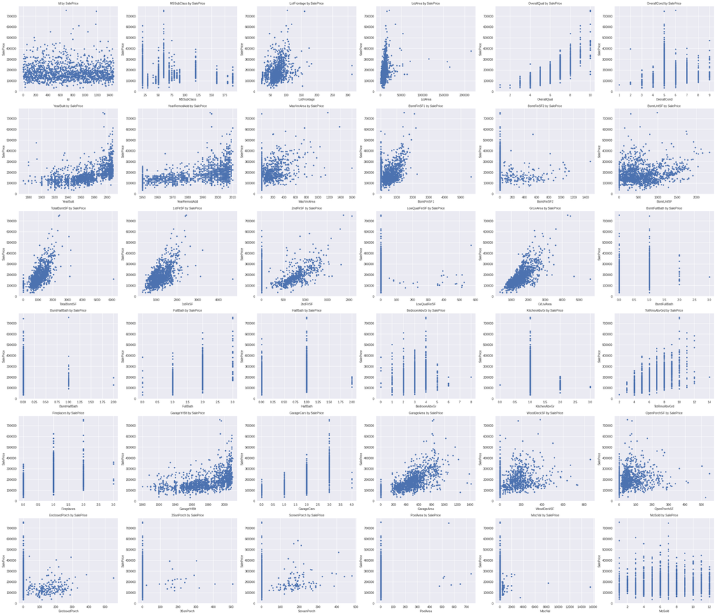

```python
# plot target values by each feature
def plot_target_values_by_each_feature(df, target_column_name):
    nrows = math.ceil(math.sqrt(len(df.columns)-2))
    ncols = math.ceil((len(df.columns)-2)/nrows)
    plt.style.use('seaborn')
    fig, axes = plt.subplots(nrows, ncols)
    plt.subplots_adjust(top=5, bottom=0, left=0, right=4)

    counter = 0
    for i in range(len(df.columns)-2):
        df.plot(kind='scatter', x=df.columns[i], y=target_column_name, title=f'{df.columns[i]} by {target_column_name}', ax=axes[i//nrows, i%nrows])
        axes[i//nrows, i%nrows].tick_params(axis='both', labelsize=10)
        axes[i//nrows, i%nrows].xaxis.label.set_size(10)
        axes[i//nrows, i%nrows].yaxis.label.set_size(10)
        axes[i//nrows, i%nrows].title.set_fontsize(10)

    for i in range(len(df.columns)-2, nrows*ncols):
        fig.delaxes(axes.flatten()[i])

numerical_data = train_df.select_dtypes(include=['int64', 'float64'])
plot_target_values_by_each_feature(numerical_data, 'SalePrice')
```

## Removing Outliars

```python
# GrLivArea
# Finding the outliars:
display(train_df.loc[train_df['GrLivArea'] > 4500]['GrLivArea'])
# 1stFlrSF
# Finding the outliars:
display(train_df.loc[train_df['1stFlrSF'] > 4000]['1stFlrSF'])
# TotalBsmtSF
# Finding the outliars:
display(train_df.loc[train_df['TotalBsmtSF'] > 6000]['TotalBsmtSF'])
# BsmtFinSF1
# Finding the outliars:
display(train_df.loc[train_df['BsmtFinSF1'] > 5000]['BsmtFinSF1'])
# Dropping:
train_df.drop([523, 1298], inplace=True)
train_df = train_df.reset_index()
```

```
523     4676
1298    5642
Name: GrLivArea, dtype: int64
```

```
1298    4692
Name: 1stFlrSF, dtype: int64
```

```
1298    6110
Name: TotalBsmtSF, dtype: int64
```

```
1298    5644
Name: BsmtFinSF1, dtype: int64
```

```python
train_df.drop(['index'], axis=1, inplace=True)
```

## Correlations

We want to find out if there are features with high correlation with `SalePrice`.  
By looking at the scatterplots above we can see that these features are correlated with `SalePrice`:

- `OverallQual`
- `TotalBsmtSF`
- `1stFlrFS`
- `GrLivArea`
- `GarageCars`
- `GarageArea`

We can see that many features contains the value `0`, it might be a problem and we will see if we will need to handle it later.

Let us see how it looks in a heatmap with numerical and ordinal features:

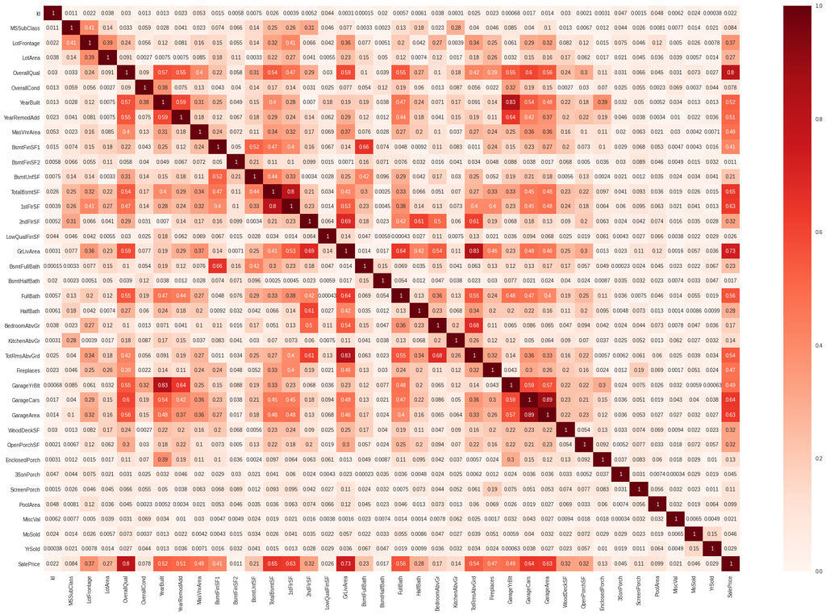

```python
def show_heatmap(df, figsize=(20, 10)):
    plt.figure(figsize=figsize)
    cor = np.abs(df.corr())
    sns.heatmap(cor, annot=True, cmap=plt.cm.Reds, vmin=0, vmax=1, annot_kws={"size": 10})
    plt.show()

show_heatmap(train_df, (30, 20))
```

We can see that there are features that has a segnificant correlation with each other so we will create new features later from the combination of them:

- `GarageCars` & `GarageArea` with 0.89
- `1stFlrSF` & `TotalBsmtSF` with 0.8
- `TotRmsAbvGrd` & `GrLivArea` with 0.83
- `YearBuilt` & `GarageYrBlt` with 0.83
- `TotRmsAbvGrd` & `BedroomAbvGr` with 0.68
- `GrLivArea` & `2ndFlrSF` with 0.69

### Categorial Features Charts

```python
# import go and make_subplots and create pie charts subplots of the categorical features
import plotly.graph_objects as go
from plotly.subplots import make_subplots
def create_pie_chart_subplot_of_count(df, columns_names):
    rows = int(np.ceil(np.sqrt(len(columns_names)))) - 2
    cols = int(np.ceil(len(columns_names)/rows)) + 2
    fig = make_subplots(rows=rows, cols=cols, specs=[[{"type": "domain"} for i in range(cols)] for j in range(rows)])
    for i, column_name in enumerate(columns_names):
        df_not_null = df[~df[column_name].isnull()]
        fig.add_trace(go.Pie(labels=df_not_null.groupby([column_name]).size().reset_index(name='count')[column_name],
                             values=df_not_null.groupby([column_name]).size().reset_index(name='count')['count'],
                             name=column_name),
                      (i)//cols+1, (i)%cols+1)
    fig.update_layout(margin=dict(t=10, l=10, r=10, b=10))
    fig.show()

train_categorical_df = categorical_cols = train_df.select_dtypes(include=['object', 'bool'])
create_pie_chart_subplot_of_count(train_categorical_df, train_categorical_df.columns[:10])
create_pie_chart_subplot_of_count(train_categorical_df, train_categorical_df.columns[10:20])
create_pie_chart_subplot_of_count(train_categorical_df, train_categorical_df.columns[20:30])
create_pie_chart_subplot_of_count(train_categorical_df, train_categorical_df.columns[30:])
```

[interactive chart not shown]

## Data Cleansing

- `PoolQC`
- `MiscFeature`
- `Alley`
- `Fence`

```python
train_df = train_df.drop(['PoolQC' ,'MiscFeature', 'Alley', 'Fence'], axis=1)
missing_data = missing_data.drop(['PoolQC' ,'MiscFeature', 'Alley', 'Fence'])

test_df = test_df.drop(['PoolQC' ,'MiscFeature', 'Alley', 'Fence'], axis=1)
missing_data_test = missing_data_test.drop(['PoolQC' ,'MiscFeature', 'Alley', 'Fence'])
```

### Replacing null value

```python
# fill empty values in the dataframe
def fill_na_median(df, column_name):
    df_not_null = df[~df[column_name].isnull()]
    df[column_name].fillna(df_not_null[column_name].median(), inplace=True)

def fill_na_mean(df, column_name):
    df_not_null = df[~df[column_name].isnull()]
    df[column_name].fillna(df_not_null[column_name].mean(), inplace=True)

def fill_na_freq(df, column_name):
    df_not_null = df[~df[column_name].isnull()]
    df[column_name].fillna(df_not_null[column_name].max(), inplace=True)


# count empty values in each column
def count_empty_values_in_each_column(df):
    print('empty values:')
    code = "len(np.where(df[column].isnull())[0])"
    for column in df.columns:
        print(f'`{column}`: {eval(code)}')

count_empty_values_in_each_column(train_df)

for feature in missing_data.index:
    if str(missing_data['Type'][feature]) == 'object':
        fill_na_freq(train_df, feature)
    else:
        fn = random.choice([fill_na_median, fill_na_mean])
        fn(train_df, feature)

print('-----------------------------------')
print('-----------------------------------')
count_empty_values_in_each_column(test_df)

for feature in missing_data_test.index:
    if str(missing_data_test['Type'][feature]) == 'object':
        fill_na_freq(test_df, feature)
    else:
        fn = random.choice([fill_na_median, fill_na_mean])
        fn(test_df, feature)
```

```
empty values:
`Id`: 0
`MSSubClass`: 0
`MSZoning`: 0
`LotFrontage`: 259
`LotArea`: 0
`Street`: 0
`LotShape`: 0
`LandContour`: 0
`Utilities`: 0
`LotConfig`: 0
`LandSlope`: 0
`Neighborhood`: 0
`Condition1`: 0
`Condition2`: 0
`BldgType`: 0
`HouseStyle`: 0
`OverallQual`: 0
`OverallCond`: 0
`YearBuilt`: 0
`YearRemodAdd`: 0
`RoofStyle`: 0
`RoofMatl`: 0
`Exterior1st`: 0
`Exterior2nd`: 0
`MasVnrType`: 8
`MasVnrArea`: 8
`ExterQual`: 0
`ExterCond`: 0
`Foundation`: 0
`BsmtQual`: 37
`BsmtCond`: 37
`BsmtExposure`: 38
`BsmtFinType1`: 37
`BsmtFinSF1`: 0
`BsmtFinType2`: 38
`BsmtFinSF2`: 0
`BsmtUnfSF`: 0
`TotalBsmtSF`: 0
`Heating`: 0
```

[output cut: 102 more lines]

```
`GarageArea`: 1
`GarageQual`: 78
`GarageCond`: 78
`PavedDrive`: 0
`WoodDeckSF`: 0
`OpenPorchSF`: 0
`EnclosedPorch`: 0
`3SsnPorch`: 0
`ScreenPorch`: 0
`PoolArea`: 0
`MiscVal`: 0
`MoSold`: 0
`YrSold`: 0
`SaleType`: 1
`SaleCondition`: 0
```

Now we can see that there are no null values in our data:

```python
count_empty_values_in_each_column(train_df)
print('-----------------------------------')
print('-----------------------------------')
count_empty_values_in_each_column(test_df)
```

```
empty values:
`Id`: 0
`MSSubClass`: 0
`MSZoning`: 0
`LotFrontage`: 0
`LotArea`: 0
`Street`: 0
`LotShape`: 0
`LandContour`: 0
`Utilities`: 0
`LotConfig`: 0
`LandSlope`: 0
`Neighborhood`: 0
`Condition1`: 0
`Condition2`: 0
`BldgType`: 0
`HouseStyle`: 0
`OverallQual`: 0
`OverallCond`: 0
`YearBuilt`: 0
`YearRemodAdd`: 0
`RoofStyle`: 0
`RoofMatl`: 0
`Exterior1st`: 0
`Exterior2nd`: 0
`MasVnrType`: 0
`MasVnrArea`: 0
`ExterQual`: 0
`ExterCond`: 0
`Foundation`: 0
`BsmtQual`: 0
`BsmtCond`: 0
`BsmtExposure`: 0
`BsmtFinType1`: 0
`BsmtFinSF1`: 0
`BsmtFinType2`: 0
`BsmtFinSF2`: 0
`BsmtUnfSF`: 0
`TotalBsmtSF`: 0
`Heating`: 0
```

[output cut: 102 more lines]

```
`GarageArea`: 0
`GarageQual`: 0
`GarageCond`: 0
`PavedDrive`: 0
`WoodDeckSF`: 0
`OpenPorchSF`: 0
`EnclosedPorch`: 0
`3SsnPorch`: 0
`ScreenPorch`: 0
`PoolArea`: 0
`MiscVal`: 0
`MoSold`: 0
`YrSold`: 0
`SaleType`: 0
`SaleCondition`: 0
```

```python
t = train_df['SalePrice'].copy()
X = train_df.drop(['SalePrice'], axis=1)
print('target:')
display(t)
print()
print('X:')
display(X)
```

```
target:
```

```
0       208500
1       181500
2       223500
3       140000
4       250000
         ...
1453    175000
1454    210000
1455    266500
1456    142125
1457    147500
Name: SalePrice, Length: 1458, dtype: int64
```

```
X:
```

|  | Id | MSSubClass | MSZoning | LotFrontage | LotArea | Street | LotShape | LandContour | Utilities | LotConfig | ... | OpenPorchSF | EnclosedPorch | 3SsnPorch | ScreenPorch | PoolArea | MiscVal | MoSold | YrSold | SaleType | SaleCondition |
| --- | --- | --- | --- | --- | --- | --- | --- | --- | --- | --- | --- | --- | --- | --- | --- | --- | --- | --- | --- | --- | --- |
| 0 | 1 | 60 | RL | 65.0 | 8450 | Pave | Reg | Lvl | AllPub | Inside | ... | 61 | 0 | 0 | 0 | 0 | 0 | 2 | 2008 | WD | Normal |
| 1 | 2 | 20 | RL | 80.0 | 9600 | Pave | Reg | Lvl | AllPub | FR2 | ... | 0 | 0 | 0 | 0 | 0 | 0 | 5 | 2007 | WD | Normal |
| 2 | 3 | 60 | RL | 68.0 | 11250 | Pave | IR1 | Lvl | AllPub | Inside | ... | 42 | 0 | 0 | 0 | 0 | 0 | 9 | 2008 | WD | Normal |
| 3 | 4 | 70 | RL | 60.0 | 9550 | Pave | IR1 | Lvl | AllPub | Corner | ... | 35 | 272 | 0 | 0 | 0 | 0 | 2 | 2006 | WD | Abnorml |
| 4 | 5 | 60 | RL | 84.0 | 14260 | Pave | IR1 | Lvl | AllPub | FR2 | ... | 84 | 0 | 0 | 0 | 0 | 0 | 12 | 2008 | WD | Normal |
| ... | ... | ... | ... | ... | ... | ... | ... | ... | ... | ... | ... | ... | ... | ... | ... | ... | ... | ... | ... | ... | ... |
| 1453 | 1456 | 60 | RL | 62.0 | 7917 | Pave | Reg | Lvl | AllPub | Inside | ... | 40 | 0 | 0 | 0 | 0 | 0 | 8 | 2007 | WD | Normal |
| 1454 | 1457 | 20 | RL | 85.0 | 13175 | Pave | Reg | Lvl | AllPub | Inside | ... | 0 | 0 | 0 | 0 | 0 | 0 | 2 | 2010 | WD | Normal |
| 1455 | 1458 | 70 | RL | 66.0 | 9042 | Pave | Reg | Lvl | AllPub | Inside | ... | 60 | 0 | 0 | 0 | 0 | 2500 | 5 | 2010 | WD | Normal |
| 1456 | 1459 | 20 | RL | 68.0 | 9717 | Pave | Reg | Lvl | AllPub | Inside | ... | 0 | 112 | 0 | 0 | 0 | 0 | 4 | 2010 | WD | Normal |
| 1457 | 1460 | 20 | RL | 75.0 | 9937 | Pave | Reg | Lvl | AllPub | Inside | ... | 68 | 0 | 0 | 0 | 0 | 0 | 6 | 2008 | WD | Normal |

1458 rows × 76 columns

```python
numerical_cols = X.select_dtypes(include=['int64', 'float64']).columns
categorical_cols = X.select_dtypes(include=['object', 'bool']).columns
all_cols = categorical_cols.tolist() + numerical_cols.tolist()
ct_enc_std = ColumnTransformer([
            ("encoding", OrdinalEncoder(), categorical_cols),
            ("standard", StandardScaler(), numerical_cols)])
X_encoded = pd.DataFrame(ct_enc_std.fit_transform(X, t), columns=all_cols)
display(X_encoded)
```

|  | MSZoning | Street | LotShape | LandContour | Utilities | LotConfig | LandSlope | Neighborhood | Condition1 | Condition2 | ... | GarageArea | WoodDeckSF | OpenPorchSF | EnclosedPorch | 3SsnPorch | ScreenPorch | PoolArea | MiscVal | MoSold | YrSold |
| --- | --- | --- | --- | --- | --- | --- | --- | --- | --- | --- | --- | --- | --- | --- | --- | --- | --- | --- | --- | --- | --- |
| 0 | 3.0 | 1.0 | 3.0 | 3.0 | 0.0 | 4.0 | 0.0 | 5.0 | 2.0 | 2.0 | ... | 0.357973 | -0.750831 | 0.225982 | -0.359603 | -0.11642 | -0.270407 | -0.063709 | -0.087748 | -1.601578 | 0.138375 |
| 1 | 3.0 | 1.0 | 3.0 | 3.0 | 0.0 | 2.0 | 0.0 | 24.0 | 1.0 | 2.0 | ... | -0.056795 | 1.627328 | -0.708304 | -0.359603 | -0.11642 | -0.270407 | -0.063709 | -0.087748 | -0.490155 | -0.614427 |
| 2 | 3.0 | 1.0 | 0.0 | 3.0 | 0.0 | 4.0 | 0.0 | 5.0 | 2.0 | 2.0 | ... | 0.640770 | -0.750831 | -0.065025 | -0.359603 | -0.11642 | -0.270407 | -0.063709 | -0.087748 | 0.991743 | 0.138375 |
| 3 | 3.0 | 1.0 | 0.0 | 3.0 | 0.0 | 0.0 | 0.0 | 6.0 | 2.0 | 2.0 | ... | 0.801022 | -0.750831 | -0.172238 | 4.089589 | -0.11642 | -0.270407 | -0.063709 | -0.087748 | -1.601578 | -1.367230 |
| 4 | 3.0 | 1.0 | 0.0 | 3.0 | 0.0 | 2.0 | 0.0 | 15.0 | 2.0 | 2.0 | ... | 1.715398 | 0.781406 | 0.578253 | -0.359603 | -0.11642 | -0.270407 | -0.063709 | -0.087748 | 2.103167 | 0.138375 |
| ... | ... | ... | ... | ... | ... | ... | ... | ... | ... | ... | ... | ... | ... | ... | ... | ... | ... | ... | ... | ... | ... |
| 1453 | 3.0 | 1.0 | 3.0 | 3.0 | 0.0 | 4.0 | 0.0 | 8.0 | 2.0 | 2.0 | ... | -0.056795 | -0.750831 | -0.095658 | -0.359603 | -0.11642 | -0.270407 | -0.063709 | -0.087748 | 0.621269 | -0.614427 |
| 1454 | 3.0 | 1.0 | 3.0 | 3.0 | 0.0 | 4.0 | 0.0 | 14.0 | 2.0 | 2.0 | ... | 0.131736 | 2.034328 | -0.708304 | -0.359603 | -0.11642 | -0.270407 | -0.063709 | -0.087748 | -1.601578 | 1.643980 |
| 1455 | 3.0 | 1.0 | 3.0 | 3.0 | 0.0 | 4.0 | 0.0 | 6.0 | 2.0 | 2.0 | ... | -1.037158 | -0.750831 | 0.210665 | -0.359603 | -0.11642 | -0.270407 | -0.063709 | 4.949624 | -0.490155 | 1.643980 |
| 1456 | 3.0 | 1.0 | 3.0 | 3.0 | 0.0 | 4.0 | 0.0 | 12.0 | 2.0 | 2.0 | ... | -1.093717 | 2.169995 | -0.708304 | 1.472417 | -0.11642 | -0.270407 | -0.063709 | -0.087748 | -0.860629 | 1.643980 |
| 1457 | 3.0 | 1.0 | 3.0 | 3.0 | 0.0 | 4.0 | 0.0 | 7.0 | 2.0 | 2.0 | ... | -0.924039 | 5.122743 | 0.333195 | -0.359603 | -0.11642 | -0.270407 | -0.063709 | -0.087748 | -0.119680 | 0.138375 |

1458 rows × 76 columns

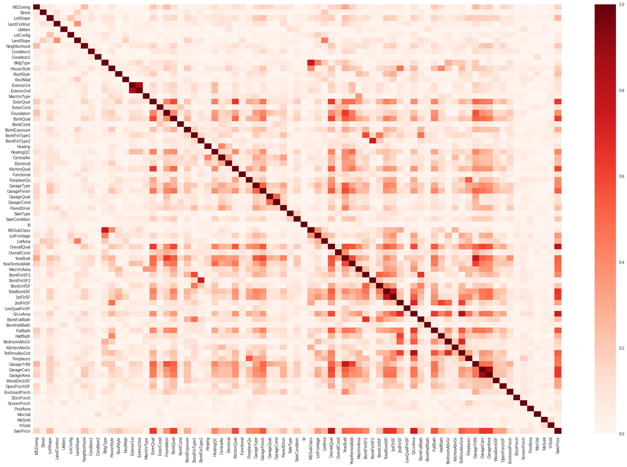

```python
X_t_encoded = X_encoded.copy()
X_t_encoded['SalePrice'] = t.copy()

plt.figure(figsize=(30, 20))
cor = np.abs(X_t_encoded.corr())
sns.heatmap(cor, cmap=plt.cm.Reds, vmin=0, vmax=1)
plt.show()
```

## Combining features and creating new ones

I will create new features for:

- `GarageCars` & `GarageArea`
- `1stFlrSF` & `TotalBsmtSF`
- `TotRmsAbvGrd` & `GrLivArea`
- `YearBuilt` & `GarageYrBlt`
- `TotRmsAbvGrd` & `BedroomAbvGr`
- `GrLivArea` & `2ndFlrSF`

```python
combined_df = [X, test_df]

for df in combined_df:
    df['GarageArea_Cars'] = df['GarageArea'] * df['GarageCars']
    df['1stFlr_BsmtSF'] = df['1stFlrSF'] + df['TotalBsmtSF']
    df['TotRmsAbvGrd_GrLivArea'] = df['TotRmsAbvGrd'] + df['GrLivArea']
    df['YearBuilt_With_Garage'] = df['YearBuilt'] + df['GarageYrBlt']
    df['TotRmsAbvGrd_BedroomAbvGr'] = df['TotRmsAbvGrd'] + df['BedroomAbvGr']
    df['GrLivArea_2ndFlrSF'] = df['GrLivArea'] + df['2ndFlrSF']


    df.drop(['GarageArea', 'GarageCars', '1stFlrSF', "TotalBsmtSF", "TotRmsAbvGrd", 'GrLivArea', 'YearBuilt', 'GarageYrBlt', 'BedroomAbvGr', '2ndFlrSF'], axis=1, inplace=True)
```

We now have 72 features left:

```python
len(X.columns)
```

```
72
```

## Cross-Validation

```python
def find_generator_len(generator, use_pbar=True):
    i = 0

    if use_pbar:
        pbar = tqdm(desc='Calculating Length', ncols=1000, bar_format='{desc}{bar:10}{r_bar}')

    for a in generator:
        i += 1

        if use_pbar:
            pbar.update()

    if use_pbar:
        pbar.close()

    return i
```

```python
# calculate score and loss from cv (KFold or LPO) and display graphs
def get_cv_score_and_loss(X, t, model, transformer=None, k=None, p=None, show_score_loss_graphs=False, use_pbar=True):
    scores_losses_df = pd.DataFrame(columns=['fold_id', 'split', 'score', 'loss'])

    if k is not None:
        cv = KFold(n_splits=k, shuffle=True, random_state=1)
    elif p is not None:
        cv = LeavePOut(p)
    else:
        raise ValueError('you need to specify k or p in order for the cv to work')

    if use_pbar:
        pbar = tqdm(desc='Computing Models', total=find_generator_len(cv.split(X)))

    for i, (train_ids, val_ids) in enumerate(cv.split(X)):
        X_train = X.loc[train_ids]
        t_train = t.loc[train_ids]
        X_val = X.loc[val_ids]
        t_val = t.loc[val_ids]

        model.fit(X_train, t_train)

        y_train = model.predict(X_train)
        y_val = model.predict(X_val)
        scores_losses_df.loc[len(scores_losses_df)] = [i, 'train', model.score(X_train, t_train), mean_squared_error(t_train, y_train, squared=False)]
        scores_losses_df.loc[len(scores_losses_df)] = [i, 'val', model.score(X_val, t_val), mean_squared_error(t_val, y_val, squared=False)]

        if use_pbar:
            pbar.update()

    if use_pbar:
        pbar.close()

    val_scores_losses_df = scores_losses_df[scores_losses_df['split']=='val']
    train_scores_losses_df = scores_losses_df[scores_losses_df['split']=='train']

    mean_val_score = val_scores_losses_df['score'].mean()
    mean_val_loss = val_scores_losses_df['loss'].mean()
    mean_train_score = train_scores_losses_df['score'].mean()
    mean_train_loss = train_scores_losses_df['loss'].mean()

    if show_score_loss_graphs:
        fig = px.line(scores_losses_df, x='fold_id', y='score', color='split', title=f'Mean Val Score: {mean_val_score:.2f}, Mean Train Score: {mean_train_score:.2f}')
        fig.show()
        fig = px.line(scores_losses_df, x='fold_id', y='loss', color='split', title=f'Mean Val Loss: {mean_val_loss:.2f}, Mean Train Loss: {mean_train_loss:.2f}')
        fig.show()

    return mean_val_score, mean_val_loss, mean_train_score, mean_train_loss
```

```python
# determine categorical and numerical features
numerical_cols = X.select_dtypes(include=['int64', 'float64']).columns
categorical_cols = X.select_dtypes(include=['object', 'bool']).columns
all_cols = np.array(X.columns)
```

First, I will use OneHotEncoding for categorical columns and StandardScaler for numerical columns to transform values.  
Then, using SGDRegressor to create the model.  
I Will use KFold, with k=20 to get CV score and loss.  
k=20 gave me the best scores.

```python
ct = ColumnTransformer([
    ("encoding", OneHotEncoder(sparse=False, handle_unknown='ignore'), categorical_cols),
    ("standard", StandardScaler(), numerical_cols)])
model_pipe = make_pipeline(ct, SGDRegressor(random_state=1))
val_score, val_loss, train_score, train_loss = get_cv_score_and_loss(X, t, model_pipe, k=20, show_score_loss_graphs=True)
print(f'mean cv val score: {val_score:.2f}\nmean cv val loss {val_loss:.2f}')
print(f'mean cv train score: {train_score:.2f}\nmean cv train loss {train_loss:.2f}')
# Prediction for this model:
Y_pred_1st = model_pipe.predict(test_df)
```

[interactive chart not shown]

```
mean cv val score: 0.91
mean cv val loss 23631.42
mean cv train score: 0.93
mean cv train loss 21186.66
```

## Feature Selection

```python
# find best subset of features on this dataset
from sklearn.feature_selection import RFECV
from sklearn.model_selection import RepeatedKFold

ct_enc_std = ColumnTransformer([
            ("encoding", OrdinalEncoder(), categorical_cols),
            ("standard", StandardScaler(), numerical_cols)])
X_encoded = pd.DataFrame(ct_enc_std.fit_transform(X, t), columns=all_cols)

selector = RFECV(SGDRegressor(random_state=1), cv=RepeatedKFold(n_splits=5, n_repeats=10, random_state=1)).fit(X_encoded, t)
display(X_encoded.loc[:, selector.support_])

fig = go.Figure()
fig.add_trace(go.Scatter(x=[i for i in range(1, len(selector.grid_scores_) + 1)], y=selector.grid_scores_))
fig.update_xaxes(title_text="Number of features selected")
fig.update_yaxes(title_text="Cross validation score (nb of correct classifications)")
fig.show()
```

|  | MSSubClass | LotConfig | Condition1 | OverallQual | OverallCond | YearRemodAdd | RoofStyle | RoofMatl | Exterior1st | Exterior2nd | ... | KitchenQual | Functional | Fireplaces | WoodDeckSF | GarageArea_Cars | 1stFlr_BsmtSF | TotRmsAbvGrd_GrLivArea | YearBuilt_With_Garage | TotRmsAbvGrd_BedroomAbvGr | GrLivArea_2ndFlrSF |
| --- | --- | --- | --- | --- | --- | --- | --- | --- | --- | --- | --- | --- | --- | --- | --- | --- | --- | --- | --- | --- | --- |
| 0 | 1.0 | 2.0 | 1.0 | 1.0 | 2.0 | 4.0 | 2.0 | 2.0 | 3.0 | 3.0 | ... | 0.521256 | 0.617283 | -0.288867 | -0.211605 | 0.172160 | -0.668263 | 0.394903 | 1.100568 | 0.720773 | 0.814952 |
| 1 | 1.0 | 2.0 | 1.0 | 2.0 | 3.0 | 4.0 | 1.0 | 2.0 | 3.0 | 1.0 | ... | -0.574405 | 1.245719 | -0.288867 | -0.211605 | -0.076804 | 0.418326 | -0.489105 | 0.043694 | -0.167551 | -0.684213 |
| 2 | 1.0 | 2.0 | 1.0 | 1.0 | 2.0 | 4.0 | 2.0 | 2.0 | 3.0 | 2.0 | ... | 0.331193 | 0.108989 | -0.288867 | -0.211605 | 0.341908 | -0.496978 | 0.540273 | 1.022281 | -0.167551 | 0.916279 |
| 3 | 1.0 | 2.0 | 1.0 | 2.0 | 3.0 | 4.0 | 0.0 | 3.0 | 1.0 | 3.0 | ... | -0.574405 | -0.514826 | -0.288867 | -0.211605 | 1.346250 | -0.661572 | 0.406690 | -0.719604 | 0.276611 | 0.710172 |
| 4 | 1.0 | 2.0 | 1.0 | 1.0 | 2.0 | 4.0 | 2.0 | 2.0 | 3.0 | 0.0 | ... | 1.382133 | 0.499451 | -0.288867 | -0.211605 | 2.169527 | 0.105195 | 1.355525 | 0.983137 | 1.609096 | 1.605987 |
| ... | ... | ... | ... | ... | ... | ... | ... | ... | ... | ... | ... | ... | ... | ... | ... | ... | ... | ... | ... | ... | ... |
| 1453 | 1.0 | 2.0 | 1.0 | 2.0 | 3.0 | 4.0 | 2.0 | 2.0 | 3.0 | 3.0 | ... | -0.574405 | -1.013878 | -0.288867 | -0.211605 | -0.076804 | -0.408659 | 0.269177 | 0.943994 | 0.276611 | 0.558183 |
| 1454 | 1.0 | 2.0 | 1.0 | 3.0 | 3.0 | 4.0 | 1.0 | 2.0 | 3.0 | 3.0 | ... | 0.090818 | 0.811359 | 0.721263 | -0.211605 | 0.036362 | 1.878262 | 1.106038 | 0.121981 | 0.276611 | 0.249599 |
| 1455 | 1.0 | 2.0 | 1.0 | 2.0 | 0.0 | 2.0 | 4.0 | 3.0 | 1.0 | 3.0 | ... | -0.574405 | -0.378511 | -0.288867 | -0.211605 | -1.021734 | 0.172104 | 1.634479 | -1.326327 | 1.609096 | 1.883482 |
| 1456 | 1.0 | 2.0 | 3.0 | 2.0 | 3.0 | 4.0 | 1.0 | 3.0 | 3.0 | 2.0 | ... | -0.574405 | -0.900667 | 6.087966 | -0.211605 | -1.038709 | -0.074118 | -0.852531 | -0.974036 | -1.055874 | -0.896077 |
| 1457 | 1.0 | 2.0 | 1.0 | 2.0 | 2.0 | 4.0 | 1.0 | 3.0 | 3.0 | 3.0 | ... | -0.574405 | 0.903776 | 1.508297 | -0.211605 | -0.987784 | 0.402268 | -0.500892 | -0.386884 | -0.167551 | -0.691122 |

1458 rows × 32 columns

[interactive chart not shown]

It shows that we need to use 32 features to get the best results.  
Then, creating the new df using only the selected features gave us CV score and loss of:

```python
X_selector = X_encoded.loc[:, selector.support_]

X_best = X[X_selector.columns]
# display(X_best)

test_best = test_df[X_selector.columns]
# display(test_best)

numerical_cols = X_best.select_dtypes(include=['int64', 'float64']).columns
categorical_cols = X_best.select_dtypes(include=['object', 'bool']).columns

ct = ColumnTransformer([
    ("encoding", OneHotEncoder(sparse=False, handle_unknown='ignore'), categorical_cols),
    ("standard", StandardScaler(), numerical_cols)])
model_pipe = make_pipeline(ct, SGDRegressor(random_state=1))
val_score, val_loss, train_score, train_loss = get_cv_score_and_loss(X_best, t, model_pipe, k=10, show_score_loss_graphs=True)
print(f'mean cv val score: {val_score:.2f}\nmean cv val loss {val_loss:.2f}')
print(f'mean cv train score: {train_score:.2f}\nmean cv train loss {train_loss:.2f}')
# Prediction for this model after selecting the best features :
Y_pred_2nd = model_pipe.predict(test_best)
```

[interactive chart not shown]

```
mean cv val score: 0.88
mean cv val loss 26853.90
mean cv train score: 0.90
mean cv train loss 25339.82
```

## Regularization

```python
from sklearn.model_selection import cross_val_score

sgd_lasso = make_pipeline(ct, SGDRegressor(penalty='l1', random_state=1))
sgd_ridge = make_pipeline(ct, SGDRegressor(penalty='l2', random_state=1))
sgd_elastic = make_pipeline(ct, SGDRegressor(penalty='elasticnet', random_state=1))

print('sgd_lasso', cross_val_score(sgd_lasso, X_best, t, cv=10).mean())
print('sgd_ridge', cross_val_score(sgd_ridge, X_best, t, cv=10).mean())
print('sgd_elastic', cross_val_score(sgd_elastic, X_best, t, cv=10).mean())
```

```
sgd_lasso 0.885348260473077
sgd_ridge 0.8853496201068719
sgd_elastic 0.8853494239140014
```

## Hyper-Parameters Search

We will try to find the best hyper parameters to use with our model for better prediction:  
Using `Grid Search` and `Random Search` will tell us which will be the best one to use with our model.

## Grid Search

```python
# train with grid search and get best parameters
from sklearn.model_selection import GridSearchCV

X_normalized = ct.fit_transform(X_best)
hyper_parameters = {'penalty': ('l2', 'l1', 'elasticnet'), 'alpha':[0.0001, 0.001, 0.01, 0.1]}

gs_model = GridSearchCV(SGDRegressor(random_state=1), hyper_parameters).fit(X_normalized, t)
print('gs_model', gs_model.best_score_)
print('best params', gs_model.best_params_)
```

```
gs_model 0.8825466991956017
best params {'alpha': 0.001, 'penalty': 'elasticnet'}
```

## Random Search

```python
# train with random search and get best parameters
from sklearn.model_selection import RandomizedSearchCV
from scipy.stats import uniform

np.random.seed(1)
distributions = dict(alpha=uniform(loc=0, scale=1), penalty=['l2', 'l1', 'elasticnet'])

rs_model = RandomizedSearchCV(SGDRegressor(), distributions, random_state=1).fit(X_normalized, t)
print('rs_model', rs_model.best_score_)
print('best params', rs_model.best_params_)
```

```
rs_model 0.8824864631559739
best params {'alpha': 0.8781174363909454, 'penalty': 'l1'}
```

```python
model_pipe = make_pipeline(ct, SGDRegressor(random_state=1, penalty='l2'))
val_score, val_loss, train_score, train_loss = get_cv_score_and_loss(X_best, t, model_pipe, k=10, show_score_loss_graphs=True)
print(f'mean cv val score: {val_score:.2f}\nmean cv val loss {val_loss:.2f}')
print(f'mean cv train score: {train_score:.2f}\nmean cv train loss {train_loss:.2f}')
Y_pred_ridge = model_pipe.predict(test_best)
```

[interactive chart not shown]

```
mean cv val score: 0.88
mean cv val loss 26853.90
mean cv train score: 0.90
mean cv train loss 25339.82
```

## Submission

We can see, after all the models we created that the best scores were from the full use of features, even after trying Feature Selection.  
All models were inferior to the one without changes except the added features and the removal of some.

### The Things that Succeeded

- The improvements that were good for the model were the added features and the removal of the ones that were making the model worse.
- Enhancing `KFold` with more folds reached better scores.

```python
submission = pd.DataFrame({
        "Id": test_df["Id"],
        "SalePrice": Y_pred_1st
    })

submission.to_csv('submission.csv', index=False)

submission
```

|  | Id | SalePrice |
| --- | --- | --- |
| 0 | 1461 | 100445.427286 |
| 1 | 1462 | 156457.036708 |
| 2 | 1463 | 186168.519335 |
| 3 | 1464 | 186766.295073 |
| 4 | 1465 | 192312.064814 |
| ... | ... | ... |
| 1454 | 2915 | 86077.054645 |
| 1455 | 2916 | 66489.036340 |
| 1456 | 2917 | 174762.963412 |
| 1457 | 2918 | 105695.239432 |
| 1458 | 2919 | 215086.828354 |

1459 rows × 2 columns

After trying several models, the best score I received was `0.15275`:

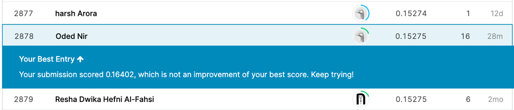

That is without the use of Feature Engineering and Regularization.

When trying the model with all the above, I received a score of `0.16402`:

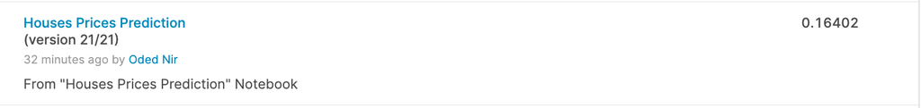

## Sources

**'Comprehensive data exploration with Python'** by [Pedro Marcelino](https://www.kaggle.com/pmarcelino):  
https://www.kaggle.com/pmarcelino/comprehensive-data-exploration-with-python